# Introduction to Causal Modeling: Structural Causal Models

Oisin Ryan

# Data and R-packages

Throughout this practical you will make use of various R-packages. If you haven’t already, install the following packages, and load them:

```r
# Load packages
library(tidyverse)  # For dplyr, ggplot, and friends
library(ggdag)      # For plotting DAGs
library(dagitty)    # For working with DAG logic
```

In this lab we’ll get some practice performing causal inference using Structural Causal Models and Directed Acyclic Graphs.

# Exercise 1

We’ll use a new simulated dataset `mdata.RDS`

```r
mdata <- readRDS("mdata.RDS")
```

## Predictive Analysis

Before we start working with DAGs, let’s try to analyze this dataset without using any DAG or potential-outcome ideas. Say we are trying to build a prediction model for `mal`, and we are pretty sure that the use of mosquito nets `net` has a strong predictive effect.

$\blacktriangleright$ Try applying your favourite prediction tool, and interpret the part of your model which relates net usage to malaria risk. Below I’ll use linear regression

```r
mod1 <- lm(mal ~ net + Income + health, data = mdata)
summary(mod1)
```

```
##
## Call:
## lm(formula = mal ~ net + Income + health, data = mdata)
##
## Residuals:
##      Min       1Q   Median       3Q      Max
## -1.29029 -0.24001 -0.00301  0.24026  1.28304
##
## Coefficients:
##              Estimate Std. Error  t value Pr(>|t|)
## (Intercept) -0.004812   0.004905   -0.981    0.327
## net         -0.504389   0.008946  -56.379   <2e-16 ***
## Income      -0.748618   0.004485 -166.920   <2e-16 ***
## health       0.248199   0.002029  122.298   <2e-16 ***
## ---
## Signif. codes:  0 '***' 0.001 '**' 0.01 '*' 0.05 '.' 0.1 ' ' 1
##
## Residual standard error: 0.3527 on 14996 degrees of freedom
## Multiple R-squared:  0.8859, Adjusted R-squared:  0.8859
## F-statistic: 3.881e+04 on 3 and 14996 DF,  p-value: < 2.2e-16
```

If we were to interpret these predictive relationships *causally* we would infer that using nets decreases malaria risk by about .5 points. We would infer that Income has a stronger negative effect on malaria risk, and that health has a weakly positive causal effect on malaria risk.

Of course, these conclusions shouldn’t be taken at face value. The researchers are interested in the **causal effect** of net usage on malaria risk. But here, we have only analyzed the **predictive relationship** between nets and malaria risk, conditional on income and health: that is, what information does net usage add to our prediction of malaria risk above and beyond the predictive information supplied by income and health.

## Drawing DAGs

Now let’s approach this analysis using a causal perspective. First, let’s begin by representing our beliefs about the causal system in a DAG. We believe that:

[output not shown]

We can draw a DAG which encodes these beliefs using `dagify()` and `ggdag()`. In `dagify` we specify each outcome variable and it’s causes, much like what the syntax for a linear regression looks like

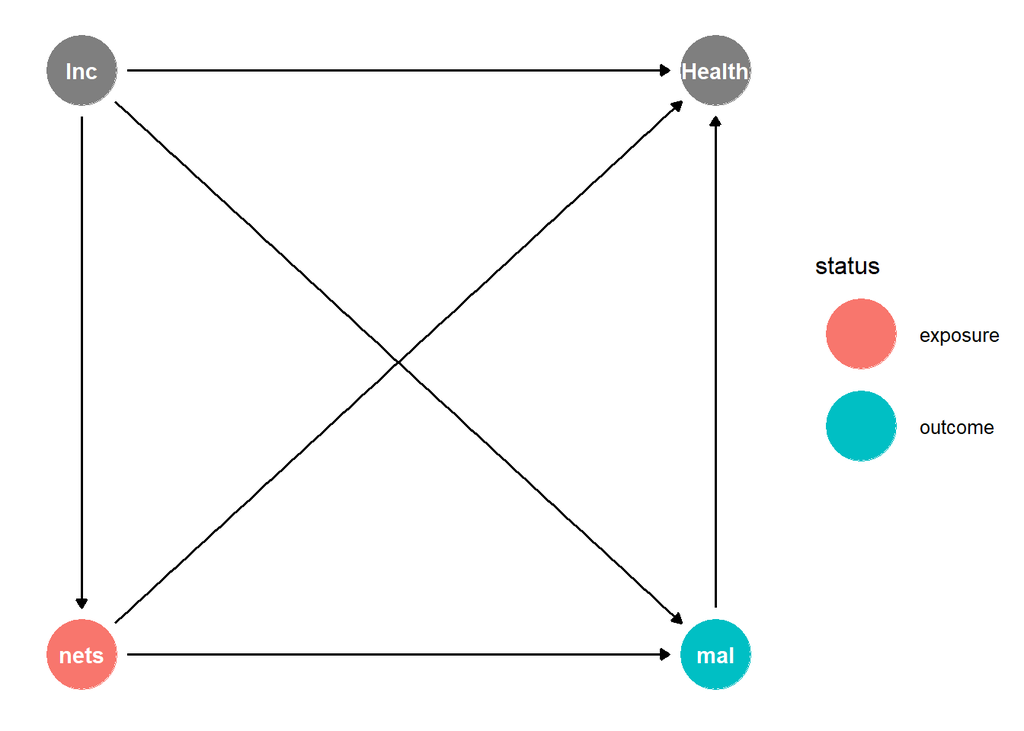

```r
maldag <- dagify(
  mal ~ nets + Inc,
  nets ~ Inc,
  Health ~ nets + Inc + mal,
  exposure = "nets", # the "cause" variable you are interested in
  outcome = "mal", # the "effect" variable you are interested in
  # optional: give co-ordinates of the variables in the plot
  coords = list(x = c(nets = -1, mal = 1, Inc = -1, Health= 1),
                y = c(nets = -1, mal = -1, Inc = 1, Health= 1))
)
ggdag_status(maldag) + theme_dag()
```

$\blacktriangleright$ From the DAG, can you read off what variable(s) you should control for in order to estimate the causal effect of nets on mal? What is the valid adjustment set?

$\blacktriangleright$ You can identify the valid adjustment set automatically by calling `adjustmentSets()`

```r
adjustmentSets(maldag)
```

```
## { Inc }
```

This tells us that we should only condition on `Income`!

$\blacktriangleright$ Estimate the causal effect of net usage on malaria risk, using the adjustment set. Compare your conclusions to that of the predictive analysis above

```r
cemod <- lm(mal ~ net + Income, data = mdata)
summary(cemod)
```

```
##
## Call:
## lm(formula = mal ~ net + Income, data = mdata)
##
## Residuals:
##      Min       1Q   Median       3Q      Max
## -2.06251 -0.33863 -0.00107  0.34271  2.16639
##
## Coefficients:
##               Estimate Std. Error t value Pr(>|t|)
## (Intercept) -0.0001781  0.0069316  -0.026    0.979
## net         -1.0046934  0.0112443 -89.352   <2e-16 ***
## Income      -0.4959763  0.0056258 -88.160   <2e-16 ***
## ---
## Signif. codes:  0 '***' 0.001 '**' 0.01 '*' 0.05 '.' 0.1 ' ' 1
##
## Residual standard error: 0.4985 on 14997 degrees of freedom
## Multiple R-squared:  0.7721, Adjusted R-squared:  0.7721
## F-statistic: 2.54e+04 on 2 and 14997 DF,  p-value: < 2.2e-16
```

Here I condition on Income by including it as a predictor in my linear regression. Note that this isn’t the only, or necessarily the best way, to condition on Income: we apply extra non-causal statistical assumptions (such as the linearity of the relationship between Income and malaria). Notice that we could also have chosen to use any of the propensity score methods we saw in the first part of the lab - if we only use Income to build the propensity score, then those methods also condition on Income! In this example, however, this will suffice.

In this analysis, we estimate the causal effect to be $-1$. This is twice as large as the predictive relationship I found by throwing everything into my linear regression model. In the predictive analysis, the estimate of the causal effect was badly biased by the inclusion of a collider! This shows that when we are interested in causal effects, careful consideration must be given to the role each variable plays in the causal graph!

## Bonus Exercise

Try approaching this research question using the techniques you learned in part 1: matching and IPW weighting. Do you make the same conclusions?

# Exercise 2

In this exercise we’ll revisit the DAG of aspirin and headache levels we saw in the lecture.

## Draw the DAG

Re-create the DAG we showed in the lecture slides using `dagify()` and `ggdag()`

```r
aspdag <- dagify(
  rec ~ asp + dehy + g + bp,
  bp ~ g + asp,
  asp ~ dehy,
  exposure = "asp", # the "cause" variable you are interested in
  outcome = "rec", # the "effect" variable you are interested in
  # create custom labels for each variable
   labels = c(rec= "Recovery from Headache", asp = "aspirin intake",
              dehy = "dehydration", g = "gender", bp = "blood pressure")
)
ggdag_status(aspdag, use_labels = "label", text = FALSE) +
  guides(fill = "none", color = "none") +  # Disable the legend
  theme_dag()
```

[output not shown]

The packages we have loaded give us a lot of tools with which to analyze DAG structure. For instance, we know that we can read off conditional independence relations between pairs of variables in the graph. But we can also do this automatically using the function `impliedConditionalIndependencies()`

$\blacktriangleright$ using the three basic graph structures we covered in the lecture, try to read off some independence relationships. Check these with R

```r
impliedConditionalIndependencies(aspdag)
```

$\blacktriangleright$ Try to list all of the paths from Aspirin to to Recovery through other variables in the DAG. You can check this using `paths()`. What paths are open and do you want to block (by conditioning), what paths are blocked already, and what paths do you not want to block?

```r
paths(aspdag)
```

$\blacktriangleright$ You can find a valid adjustment set as we did above. Notice there is typically more than one adjustment set you could choose!

```r
adjustmentSets(aspdag, type = "all")
```

## Bonus exercise

Try to set up a model to generate data from this causal system. Useful functions are `rnorm` for normally distributed variables, and `rbinom( size = 1)` for binary variables. Doing this allows you have a toy version of the SCM: you can decide what the causal effect is, and then check that your analysis recovers the true causal effect from your simulated data!

# Exercise 3

Try to draw a DAG based on a research project you were recently involved with. Alternatively, try to draw the DAG of the emotional distress-dieting system described by Schafer and Kang. Derive valid adjustment sets, and list paths between the cause and effect variable. What do you notice?

# More Info

This was a crash course on DAG-based analyses in R. More information on tools we didn’t cover in class, and their R-implementation, can be found for example here: https://evalf21.classes.andrewheiss.com/example/dags/